# What drives customers during online purchases?

Mateusz Baryła

06.02.2021

# Introduction

During last year a retail optimization has gained a lot of attention in the data science community. The COVID-19 pandemic resulted in restrictions that brought restrictions that changed a behavior of customers. Retail industry forced the closure of physical stores. “The Next Normal” requires adaptation to new requirements and the winners are these retailers that priorities online retail. For instance in United States, e-commerce availability and hygiene caused 17 percent of consumers to leave their primary store. One of the American retailers, Instacart has already adressed issue of optimizing e-commerce and released prediction competition on kaggle with several data sets (“Instacart Market Basket Analysis” 2021). **Instacart** is an online American retailer that uses advanced analytics algorithms to provide best experience for their customers.

# Datase preprocessing

## Instacart Market Basket loading

Firstly all the data need to be loaded to the R environment.

```r
aisles <- read.csv("data\\aisles.csv", sep=",")
departments <- read.csv("data\\departments.csv", sep=",")
order_products_train <- read.csv("data\\order_products__train.csv", sep=",")
orders <- read.csv("data\\orders.csv", sep=",")
products <- read.csv("data\\products.csv", sep=",")
random_names <- read.csv("E:\\GitHub\\unsupervised-learning\\data\\random_names.csv", sep=",")
```

Then in order to reduce the number of rows sample fraction out of order products is taken. We take 50% of transactions which still result in more than half a million transactions.

```r
set.seed(0402)
trans <-
  order_products_train %>%
  sample_frac(size = 0.5) %>%
  inner_join(products, by = "product_id", keep = FALSE) %>%
  inner_join(aisles, by = "aisle_id", keep = FALSE) %>%
  inner_join(orders, by = "order_id", keep = FALSE) %>%
  inner_join(departments, by ="department_id", keep = FALSE)
```

## Preprocessing

A transactional data set is not very easy in interpretation in current format. As for now data set contains a lot of ids which are not very interpretable. A decision has been made to perform several transformation which will result in transactional data.

```r
kable_head <- function(df){
  df %>% kable() %>% head()
}
```

```r
day_of_week <-
  tibble(day_id = 0:6,
         dow_name = c("Monday", "Tuesday", "Wednesday", "Thursday", "Friday", "Saturday", "Sunday")
         )

day_of_week %>% kable_head
```

[1] "

| day_id | dow_name |
| --- | --- |
| 0 | Monday |
| 1 | Tuesday |
| 2 | Wednesday |
| 3 | Thursday |
| 4 | Friday |
| 5 | Saturday |
| 6 | Sunday |

"

```r
reordered_df <-
  tibble(reordered_id = 0:1,
         reorder_name = c("Not reordered", "Reordered")
         )

reordered_df %>% kable_head
```

[1] "

| reordered_id | reorder_name |
| --- | --- |
| 0 | Not reordered |
| 1 | Reordered |

"

```r
order_hour_of_day <-
  tibble(
       hour_id = 0:23,
       time_of_day = c(rep("Night",6), rep("Morning", 4), rep("Senior hours", 2),
                    rep("Noon", 2), rep("Afternoon", 4), rep("Early night",4), rep("Night", 2))
       )

order_hour_of_day %>% kable_head
```

[1] "

| hour_id | time_of_day |
| --- | --- |
| 0 | Night |
| 1 | Night |
| 2 | Night |
| 3 | Night |
| 4 | Night |
| 5 | Night |
| 6 | Morning |
| 7 | Morning |
| 8 | Morning |
| 9 | Morning |
| 10 | Senior hours |
| 11 | Senior hours |
| 12 | Noon |
| 13 | Noon |
| 14 | Afternoon |
| 15 | Afternoon |
| 16 | Afternoon |
| 17 | Afternoon |
| 18 | Early night |
| 19 | Early night |
| 20 | Early night |
| 21 | Early night |
| 22 | Night |
| 23 | Night |

"

Above three mapping tables have been created. First two ones are self explanatory, for hour of the day six time periods have been assigned for further analysis.

```r
trans_for_ar <-
  trans %>%
  inner_join(day_of_week, by = c("order_dow" = "day_id")) %>%
  inner_join(reordered_df, by = c("reordered" = "reordered_id")) %>%
  inner_join(order_hour_of_day, by = c("order_hour_of_day" = "hour_id")) %>%
  inner_join(random_names, by = c("user_id"= "user_id")) %>%
  select(-aisle_id, -department_id, -eval_set,
         -product_id, -order_dow, - reordered,
         -order_hour_of_day, -days_since_prior_order,
         -order_number, -add_to_cart_order, -user_id) %>%
  arrange(order_id, user_name)
```

Transactions are combined in one big dataframe, id columns are removed. Columns that are also redundant in terms of analysis is eval_set. Since the chosen data set is very large and only a sample of it has been taken into account the column days_since_prior_order does not make a lot of sense since as for now not every user has order number 1 associated. Therefore there is a decision to omit this column as well order_number.

```r
trans <- as(trans_for_ar, "transactions")
```

```r
trans_for_viz <- as(trans_for_ar %>% select(product_name, aisle, department), "transactions")
```

The final transactional dataframe is made of the following attributes:

- order_id - needed for an unique transaction specification
- product_name - full product name
- aisle - aisle name that identifies, where the product belongs inside the store
- department - there are 21 department names in the store
- dow_name - identifies day of week when order has been made
- reorder_name - whether the product has been reordered or not
- time_of_day - artificially created time of the day based on column value specification
- user_name - artificial user name assigned for easier identification than original user_id

# Association rules

## General view

Association rules are often used for reducing number of transactions in the databases where each row is coded by binary attributes. There is no need for them to be trained nor to be labeled beforehand. Most common applications are found in the market basket analysis, discovering interesting patterns of DNA and protein sequences, common patterns of behavior can be found for customers that proceed customers dropping their cell phone operator.

During transactional data analysis the technique of association rules and mining frequent itemsets plays an important role for retail basket analysis. This technique is especially useful in mining patterns inside large databases. What is the most frequently used are such statistics as frequent itemsets, maximal frequent itemsets, closed frequent itemsets and association rules.

Definition: Let I = {i1, i2, …, in} be a set of n binary attributes called items. Let D = {t1, t2, …, tn} be a set of transactions called database. Each transaction in D has a unique transaction ID and contains a subset of the items in I. The sets of items X and Y are called antecedent and consequent of the rule .

The support(X) is defined as the count of transactions that contains item X to the number of transactions in the whole data set.

The confidence of a rule is defined as conf(X => Y) = supp(X u Y)/supp(X).

Another practical measure used for adressing issue of finding too many constraints is measure called lift, whihc is defined as lift(X => Y)=supp(X u Y)/(supp(X)supp(Y)). The most common interpretation is following, it can be interpreted as the deviation of the support of the whole rule from the support expected under independence given the supports of the LHS and the RHS (Hahsler, Grün, and Hornik 2005).

## Associations mining

In order to investigate the nature of the dataset the read.transactions function has been used. Transformations lead to creating transactional matrix with 565097 rows and 132889 columns. Most frequent items are not surprisingly binary feature and transaction identificator which is order_id. There are no missing values inside the database.

## Rules found in the dataset

```r
kableRules <- function(rules, sortable){
  rules.sorted<-sort(rules, by=sortable, decreasing=TRUE)
  rules.sorted.df <- as(head(rules.sorted), "data.frame")
  rownames(rules.sorted.df) <- NULL
  rules.sorted.df %>%
    as_tibble() %>%
    mutate(across(.cols = c(support, confidence, coverage, lift, count),
                  ~round(., 4))) %>%
    kable()
}
```

```r
rules.trans<-apriori(trans, parameter=list(supp=0.1, conf=0.5),
                     control=list(verbose=FALSE))
```

```r
kableRules(rules, "confidence")
```

| rules | support | confidence | coverage | lift | count |
| --- | --- | --- | --- | --- | --- |
| {product_name=Sparkling Lemon Water} => {aisle=water seltzer sparkling water} | 0.001 | 1 | 0.001 | 37.7461 | 570 |
| {product_name=Sparkling Lemon Water} => {department=beverages} | 0.001 | 1 | 0.001 | 12.1354 | 570 |
| {aisle=cold flu allergy} => {department=personal care} | 0.001 | 1 | 0.001 | 63.2807 | 571 |
| {product_name=Organic Sticks Low Moisture Part Skim Mozzarella String Cheese} => {aisle=packaged cheese} | 0.001 | 1 | 0.001 | 33.2762 | 572 |
| {product_name=Organic Sticks Low Moisture Part Skim Mozzarella String Cheese} => {department=dairy eggs} | 0.001 | 1 | 0.001 | 6.3617 | 572 |
| {aisle=packaged meat} => {department=meat seafood} | 0.001 | 1 | 0.001 | 46.3803 | 576 |

```r
kableRules(rules, "lift")
```

| rules | support | confidence | coverage | lift | count |
| --- | --- | --- | --- | --- | --- |
| {aisle=other} => {department=other} | 0.0013 | 1.0000 | 0.0013 | 762.6140 | 741 |
| {department=other} => {aisle=other} | 0.0013 | 1.0000 | 0.0013 | 762.6140 | 741 |
| {department=pets,reorder_name=Reordered} => {aisle=cat food care} | 0.0013 | 0.6501 | 0.0020 | 324.5467 | 747 |
| {department=pets} => {aisle=dog food care} | 0.0012 | 0.3715 | 0.0032 | 313.7685 | 669 |
| {aisle=dog food care} => {department=pets} | 0.0012 | 1.0000 | 0.0012 | 313.7685 | 669 |
| {aisle=cat food care} => {department=pets} | 0.0020 | 1.0000 | 0.0020 | 313.7685 | 1132 |

```r
kableRules(rules, "count")
```

| rules | support | confidence | coverage | lift | count |
| --- | --- | --- | --- | --- | --- |
| {} => {reorder_name=Reordered} | 0.5992 | 0.5992 | 1 | 1 | 338631 |
| {} => {reorder_name=Not reordered} | 0.4008 | 0.4008 | 1 | 1 | 226466 |
| {} => {order_id=[2.28e+06,3.42e+06]} | 0.3333 | 0.3333 | 1 | 1 | 188366 |
| {} => {order_id=[1.13e+06,2.28e+06)} | 0.3333 | 0.3333 | 1 | 1 | 188366 |
| {} => {order_id=[1,1.13e+06)} | 0.3333 | 0.3333 | 1 | 1 | 188365 |
| {} => {time_of_day=Afternoon} | 0.3211 | 0.3211 | 1 | 1 | 181445 |

```r
kableRules(rules, "support")
```

| rules | support | confidence | coverage | lift | count |
| --- | --- | --- | --- | --- | --- |
| {} => {reorder_name=Reordered} | 0.5992 | 0.5992 | 1 | 1 | 338631 |
| {} => {reorder_name=Not reordered} | 0.4008 | 0.4008 | 1 | 1 | 226466 |
| {} => {order_id=[2.28e+06,3.42e+06]} | 0.3333 | 0.3333 | 1 | 1 | 188366 |
| {} => {order_id=[1.13e+06,2.28e+06)} | 0.3333 | 0.3333 | 1 | 1 | 188366 |
| {} => {order_id=[1,1.13e+06)} | 0.3333 | 0.3333 | 1 | 1 | 188365 |
| {} => {time_of_day=Afternoon} | 0.3211 | 0.3211 | 1 | 1 | 181445 |

# Questions

## Question 1

**What is the profile of transactions that are being made during Senior hours?**

```r
rules.Senior.hours<-apriori(data=trans,
                            parameter=list(supp=0.001, conf=0.08),
                            appearance=list(default="lhs", rhs= "time_of_day=Senior hours"),
                            control=list(verbose=F))
kableRules(rules.Senior.hours, "confidence")
```

| rules | support | confidence | coverage | lift | count |
| --- | --- | --- | --- | --- | --- |
| {department=beverages,dow_name=Tuesday,reorder_name=Reordered} => {time_of_day=Senior hours} | 0.0017 | 0.2023 | 0.0084 | 1.2501 | 965 |
| {department=snacks,dow_name=Tuesday,reorder_name=Reordered} => {time_of_day=Senior hours} | 0.0016 | 0.2012 | 0.0078 | 1.2431 | 889 |
| {department=beverages,dow_name=Tuesday} => {time_of_day=Senior hours} | 0.0024 | 0.1921 | 0.0124 | 1.1873 | 1351 |
| {department=household,dow_name=Monday} => {time_of_day=Senior hours} | 0.0010 | 0.1902 | 0.0054 | 1.1750 | 583 |
| {aisle=coffee} => {time_of_day=Senior hours} | 0.0012 | 0.1897 | 0.0061 | 1.1721 | 651 |
| {aisle=coffee,department=beverages} => {time_of_day=Senior hours} | 0.0012 | 0.1897 | 0.0061 | 1.1721 | 651 |

Ones may want to figure out what an empty bracker on the lhs means. As documentation claims this rule means that no matter what other items are involved the item in the rhs will be chosen with the level of confidence which is equal to support.

## Question 2

**What is the profile of transactions that are being made during Senior hours?**

```r
rules.Senior.hours<-apriori(data=trans,
                            parameter=list(supp=0.001, conf=0.08),
                            appearance=list(default="lhs", rhs= "time_of_day=Senior hours"),
                            control=list(verbose=F))
kableRules(rules.Senior.hours, "lift")
```

| rules | support | confidence | coverage | lift | count |
| --- | --- | --- | --- | --- | --- |
| {department=beverages,dow_name=Tuesday,reorder_name=Reordered} => {time_of_day=Senior hours} | 0.0017 | 0.2023 | 0.0084 | 1.2501 | 965 |
| {department=snacks,dow_name=Tuesday,reorder_name=Reordered} => {time_of_day=Senior hours} | 0.0016 | 0.2012 | 0.0078 | 1.2431 | 889 |
| {department=beverages,dow_name=Tuesday} => {time_of_day=Senior hours} | 0.0024 | 0.1921 | 0.0124 | 1.1873 | 1351 |
| {department=household,dow_name=Monday} => {time_of_day=Senior hours} | 0.0010 | 0.1902 | 0.0054 | 1.1750 | 583 |
| {aisle=coffee} => {time_of_day=Senior hours} | 0.0012 | 0.1897 | 0.0061 | 1.1721 | 651 |
| {aisle=coffee,department=beverages} => {time_of_day=Senior hours} | 0.0012 | 0.1897 | 0.0061 | 1.1721 | 651 |

```r
rules.muscles.joints.pain.relief<-apriori(data=trans,
                                          parameter=list(supp=0.0001, conf=0.000001),
                                          appearance=list(default="lhs",
                                                          rhs= "aisle=muscles joints pain relief"),
                                          control=list(verbose=F))
kableRules(rules.muscles.joints.pain.relief, "coverage")
```

| rules | support | confidence | coverage | lift | count |
| --- | --- | --- | --- | --- | --- |
| {} => {aisle=muscles joints pain relief} | 7e-04 | 0.0007 | 1.0000 | 1.0000 | 378 |
| {reorder_name=Reordered} => {aisle=muscles joints pain relief} | 2e-04 | 0.0004 | 0.5992 | 0.5739 | 130 |
| {reorder_name=Not reordered} => {aisle=muscles joints pain relief} | 4e-04 | 0.0011 | 0.4008 | 1.6371 | 248 |
| {order_id=[2.28e+06,3.42e+06]} => {aisle=muscles joints pain relief} | 2e-04 | 0.0007 | 0.3333 | 0.9841 | 124 |
| {order_id=[1.13e+06,2.28e+06)} => {aisle=muscles joints pain relief} | 2e-04 | 0.0007 | 0.3333 | 1.0794 | 136 |
| {order_id=[1,1.13e+06)} => {aisle=muscles joints pain relief} | 2e-04 | 0.0006 | 0.3333 | 0.9365 | 118 |

## Question 3

**How the Friday mood affects shoppings?**

```r
rules.friday<-apriori(data=trans,
                      parameter=list(supp=0.0001, conf=0.000001),
                      appearance=list(default="lhs", rhs= "dow_name=Friday"),
                      control=list(verbose=F))
kableRules(rules.friday, "confidence")
```

| rules | support | confidence | coverage | lift | count |
| --- | --- | --- | --- | --- | --- |
| {department=alcohol,time_of_day=Morning} => {dow_name=Friday} | 1e-04 | 0.2336 | 5e-04 | 2.0969 | 64 |
| {order_id=[1.13e+06,2.28e+06),aisle=beers coolers} => {dow_name=Friday} | 1e-04 | 0.2156 | 5e-04 | 1.9357 | 58 |
| {order_id=[1.13e+06,2.28e+06),aisle=beers coolers,department=alcohol} => {dow_name=Friday} | 1e-04 | 0.2156 | 5e-04 | 1.9357 | 58 |
| {order_id=[2.28e+06,3.42e+06],department=alcohol,reorder_name=Not reordered} => {dow_name=Friday} | 1e-04 | 0.2111 | 5e-04 | 1.8949 | 61 |
| {aisle=beers coolers,reorder_name=Not reordered} => {dow_name=Friday} | 1e-04 | 0.2098 | 5e-04 | 1.8838 | 64 |
| {aisle=beers coolers,department=alcohol,reorder_name=Not reordered} => {dow_name=Friday} | 1e-04 | 0.2098 | 5e-04 | 1.8838 | 64 |

```r
trans_for_ar %>%
  group_by(dow_name, time_of_day) %>%
  count() %>%
  ungroup() %>%
  group_by(dow_name) %>%
  mutate(perc = n/sum(n))
```

| dow_name | time_of_day | n | perc |
| --- | --- | --- | --- |
| Friday | Afternoon | 19367 | 0.30767642 |
| Friday | Early night | 10502 | 0.16684142 |
| Friday | Morning | 10072 | 0.16001017 |
| Friday | Night | 3720 | 0.05909827 |
| Friday | Noon | 9537 | 0.15151082 |
| Friday | Senior hours | 9748 | 0.15486290 |
| Monday | Afternoon | 44082 | 0.33264413 |
| Monday | Early night | 18268 | 0.13785089 |
| Monday | Morning | 18405 | 0.13888470 |
| Monday | Night | 6338 | 0.04782674 |

[output cut: 32 more lines]

The results shows that most of the purchases are being made on Friday afternoon. That is interesting why people buy alcohol in the morning rather than in the afternoon. What might also be absorbing is that people do not choose any salty food in addition to the alcoholic drinks.

```r
rules.lunch.meat<-apriori(data=trans,
                               parameter=list(supp=0.0001, conf=0.000001),
                               appearance=list(default="lhs", rhs= "aisle=lunch meat"),
                                control=list(verbose=F))
kableRules(rules.lunch.meat, "confidence")
```

| rules | support | confidence | coverage | lift | count |
| --- | --- | --- | --- | --- | --- |
| {product_name=Sliced Soppressata Salame} => {aisle=lunch meat} | 1e-04 | 1 | 1e-04 | 82.017 | 57 |
| {product_name=Rosemary Ham} => {aisle=lunch meat} | 1e-04 | 1 | 1e-04 | 82.017 | 60 |
| {product_name=Hard Salami} => {aisle=lunch meat} | 1e-04 | 1 | 1e-04 | 82.017 | 60 |
| {product_name=Deli Fresh Honey Ham, 97% Fat Free, Gluten Free} => {aisle=lunch meat} | 1e-04 | 1 | 1e-04 | 82.017 | 65 |
| {product_name=Organic Roast Beef} => {aisle=lunch meat} | 1e-04 | 1 | 1e-04 | 82.017 | 66 |
| {product_name=Uncured Diced Pancetta} => {aisle=lunch meat} | 1e-04 | 1 | 1e-04 | 82.017 | 68 |

## Question 4

**Investigate weekdays in terms of some association metrics.**

```r
rules <- apriori(trans, parameter=list(supp=0.001, conf=0.001))
```

Apriori

Parameter specification: confidence minval smax arem aval originalSupport maxtime support minlen maxlen target ext 0.001 0.1 1 none FALSE TRUE 5 0.001 1 10 rules TRUE

Algorithmic control: filter tree heap memopt load sort verbose 0.1 TRUE TRUE FALSE TRUE 2 TRUE

Absolute minimum support count: 565

```r
rules.dow.tod <- subset(rules, subset = lhs %pin% "dow_name=" & rhs %pin% "time_of_day=")
kableRules(rules.dow.tod, "confidence")
```

| rules | support | confidence | coverage | lift | count |
| --- | --- | --- | --- | --- | --- |
| {aisle=ice cream ice,dow_name=Sunday} => {time_of_day=Afternoon} | 0.0011 | 0.3826 | 0.0029 | 1.1915 | 619 |
| {aisle=ice cream ice,department=frozen,dow_name=Sunday} => {time_of_day=Afternoon} | 0.0011 | 0.3826 | 0.0029 | 1.1915 | 619 |
| {order_id=[1.13e+06,2.28e+06),department=snacks,dow_name=Sunday} => {time_of_day=Afternoon} | 0.0015 | 0.3704 | 0.0041 | 1.1536 | 849 |
| {aisle=ice cream ice,dow_name=Monday} => {time_of_day=Afternoon} | 0.0013 | 0.3694 | 0.0035 | 1.1503 | 728 |
| {aisle=ice cream ice,department=frozen,dow_name=Monday} => {time_of_day=Afternoon} | 0.0013 | 0.3694 | 0.0035 | 1.1503 | 728 |
| {aisle=yogurt,dow_name=Monday,reorder_name=Not reordered} => {time_of_day=Afternoon} | 0.0011 | 0.3675 | 0.0030 | 1.1446 | 627 |

```r
rules <- apriori(trans, parameter=list(supp=0.001, conf=0.001))
```

Apriori

Parameter specification: confidence minval smax arem aval originalSupport maxtime support minlen maxlen target ext 0.001 0.1 1 none FALSE TRUE 5 0.001 1 10 rules TRUE

Algorithmic control: filter tree heap memopt load sort verbose 0.1 TRUE TRUE FALSE TRUE 2 TRUE

Absolute minimum support count: 565

```r
rules.tod.dow <- subset(rules, subset = lhs %pin% "time_of_day=" & rhs %pin% "dow_name=")
kableRules(rules.tod.dow, "count")
```

| rules | support | confidence | coverage | lift | count |
| --- | --- | --- | --- | --- | --- |
| {time_of_day=Afternoon} => {dow_name=Monday} | 0.0780 | 0.2429 | 0.3211 | 1.0360 | 44082 |
| {time_of_day=Afternoon} => {dow_name=Sunday} | 0.0493 | 0.1537 | 0.3211 | 1.0227 | 27883 |
| {time_of_day=Afternoon} => {dow_name=Tuesday} | 0.0481 | 0.1497 | 0.3211 | 1.0062 | 27155 |
| {reorder_name=Reordered,time_of_day=Afternoon} => {dow_name=Monday} | 0.0467 | 0.2475 | 0.1889 | 1.0552 | 26411 |
| {time_of_day=Noon} => {dow_name=Monday} | 0.0407 | 0.2500 | 0.1630 | 1.0659 | 23026 |
| {time_of_day=Senior hours} => {dow_name=Monday} | 0.0396 | 0.2449 | 0.1618 | 1.0445 | 22401 |

Most of the transactions found in dataset is on Monday Afternoon.

# Visualization techniques

## Hierarchical clustering

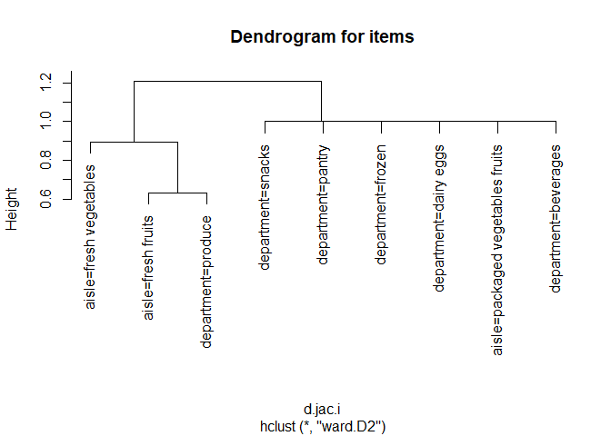

```r
trans.sel <-trans_for_viz[,itemFrequency(trans_for_viz)>0.05] # selected transations
d.jac.i<-dissimilarity(trans.sel, which="items") # Jaccard as default
plot(hclust(d.jac.i, method="ward.D2"), main="Dendrogram for items")
```

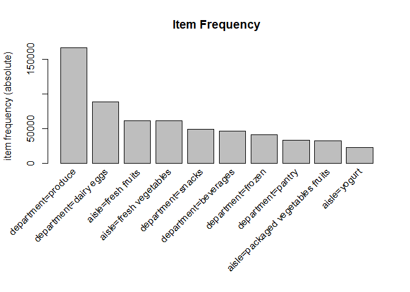

```r
itemFrequencyPlot(trans_for_viz, topN=10, type="absolute", main="Item Frequency")
```

```r
rules_for_viz <- apriori(trans_for_viz, parameter = list(support = 0.001))
```

Apriori

Parameter specification: confidence minval smax arem aval originalSupport maxtime support minlen maxlen target ext 0.8 0.1 1 none FALSE TRUE 5 0.001 1 10 rules TRUE

Algorithmic control: filter tree heap memopt load sort verbose 0.1 TRUE TRUE FALSE TRUE 2 TRUE

Absolute minimum support count: 565

[figure not shown]

```r
plot(rules_for_viz, method = "group")
```

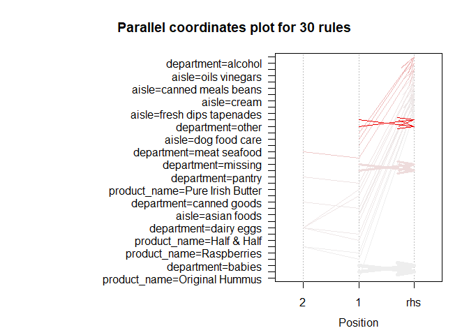

```r
plot(head(rules_for_viz, 30, by = "lift"), method = "paracoord", reorder =TRUE)
```

Figure above shows rules with arrows where the width of arrows is linked to support and the color confidence contains information about confidence of given rule. The values of each dimension are connected with each other via line. The y-axis is formed via nominal values and the x-axis presents the position in the rule.

# Conclusion

Association rules are very useful technique for mining patterns in large datasets due to their algorithms. What is more it can save a lot of time in finding user preferences and what drives their choices. Most of the useful functionalities are implemented either in a form of graphs or association rules mining functionalities. For latter arulesViz is widely used where a lot of brand new visualization techniques to research association rules has been implemented. The main features of arules in terms of association rules are efficient implementation with sparse matrices usage.

Hahsler, Michael, Bettina Grün, and Kurt Hornik. 2005. “Arules - a Computational Environment for Mining Association Rules and Frequent Item Sets.” *Journal of Statistical Software, Articles* 14 (15): 1–25. https://doi.org/10.18637/jss.v014.i15.

“Instacart Market Basket Analysis.” 2021. https://www.kaggle.com/c/instacart-market-basket-analysis. February 5, 2021.